# R Notebook

```r
# Loading the libraries that might be requred
library(readr)
library(ggplot2)
library(dplyr)
library(mosaic)
library(tidyverse)
library(tidyr)
```

## 1.From Epidemic to Pandemic

### COVID-19 was first identified in Wuhan, China, in Decemeber 2019. On 12 January 2020, Chinese authorities shared the sequence of a novel coronavirus termed severe acute respiratory syndrome coronavirus 2 (SARS-CoV-2) isolated from some clustered cases.

## Til date, we know that this can spread through respiratory system, secially through the droplets. This can be spread through coughing, sneezing, speaking or singing or any other similar form.

## Organizations have been working since almost an year for making a vaccine for this. They have been collecting data for the benefit of making a vaccine and to monitor to learn from this pandemic.

## In this notebook, we will visualize COVID-19 for the first several weeks of the outbreak to gather information about when this became a pandemic from an epidemic.

[figure not shown]

COVID-19.

```r
# Reading dataset that is going to be used for this project
confirmed_cases_worldwide <- read_csv('confirmed_cases_worldwide.csv')
# Seeing the results
head(confirmed_cases_worldwide)
```

| date | cum_cases |
| --- | --- |
| 2020-01-22 | 555 |
| 2020-01-23 | 653 |
| 2020-01-24 | 941 |
| 2020-01-25 | 1434 |
| 2020-01-26 | 2118 |
| 2020-01-27 | 2927 |

```r
summary(confirmed_cases_worldwide)
```

```
      date              cum_cases
 Min.   :2020-01-22   Min.   :   555
 1st Qu.:2020-02-04   1st Qu.: 26699
 Median :2020-02-18   Median : 75388
 Mean   :2020-02-18   Mean   : 68323
 3rd Qu.:2020-03-03   3rd Qu.: 93410
 Max.   :2020-03-17   Max.   :197146
```

```r
# Joining tables
Table1 <- read_csv('confirmed_cases_worldwide.csv')
Table2 <- read_csv('confirmed_cases_china_vs_world.csv')
innerjoin <- inner_join(Table1, Table2, by="date")
#Spread gather
spread(Table1, date, cum_cases)
```

| 2020-01-22 | 2020-01-23 | 2020-01-24 | 2020-01-25 | 2020-01-26 | 2020-01-27 | 2020-01-28 | 2020-01-29 | 2020-01-30 | 2020-01-31 | 2020-02-01 | 2020-02-02 | 2020-02-03 | 2020-02-04 | 2020-02-05 | 2020-02-06 | 2020-02-07 | 2020-02-08 | 2020-02-09 | 2020-02-10 | 2020-02-11 | 2020-02-12 | 2020-02-13 | 2020-02-14 | 2020-02-15 | 2020-02-16 | 2020-02-17 | 2020-02-18 | 2020-02-19 | 2020-02-20 | … |
| --- | --- | --- | --- | --- | --- | --- | --- | --- | --- | --- | --- | --- | --- | --- | --- | --- | --- | --- | --- | --- | --- | --- | --- | --- | --- | --- | --- | --- | --- | --- |
| 555 | 653 | 941 | 1434 | 2118 | 2927 | 5578 | 6166 | 8234 | 9927 | 12038 | 16787 | 19881 | 23892 | 27635 | 30817 | 34391 | 37120 | 40150 | 42762 | 44802 | 45221 | 60368 | 66885 | 69030 | 71224 | 73258 | 75136 | 75639 | 76197 | … |

```r
gather(Table1, date, cum_cases, 1:2)
```

```
attributes are not identical across measure variables;
they will be dropped
```

[output not shown]

[output cut: 102 more lines]

# 2.Confirmed cases throughout the world

## The graph and the table shows the cumulative cases of COVID-19 worldwide by date. The graph is required to understand the data well because just looking at the numbers of the table doenst convey a better information.

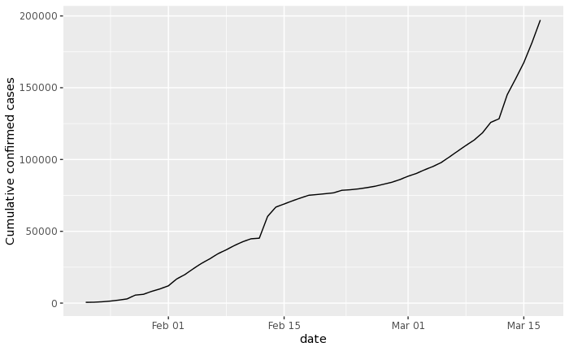

```r
# Draw a line plot of cumulative cases vs. date
# Label the y-axis
ggplot(confirmed_cases_worldwide, aes(date, cum_cases)) +
  geom_line() +
  ylab("Cumulative confirmed cases")
```

# 3.China compared to the rest of the world

## We will see some scary stats in this one. We will see how the cases rose fast in the other parts of the world compared to the china. Early on in the outbreak, the COVID-19 cases were primarily centered in China. Let’s plot confirmed COVID-19 cases in China and the rest of the world separately.

```r
# Read in the dataset confirmed_cases_china_vs_world.csv
confirmed_cases_china_vs_world <- read_csv('confirmed_cases_china_vs_world.csv')
# Results
glimpse(confirmed_cases_china_vs_world)
```

```
Observations: 112
Variables: 4
$ is_china  <chr> "China", "China", "China", "China", "China", "China", "China", "China", "China", "China", …
$ date      <date> 2020-01-22, 2020-01-23, 2020-01-24, 2020-01-25, 2020-01-26, 2020-01-27, 2020-01-28, 2020-…
$ cases     <dbl> 548, 95, 277, 486, 669, 802, 2632, 578, 2054, 1661, 2089, 4739, 3086, 3991, 3733, 3147, 35…
$ cum_cases <dbl> 548, 643, 920, 1406, 2075, 2877, 5509, 6087, 8141, 9802, 11891, 16630, 19716, 23707, 27440…
```

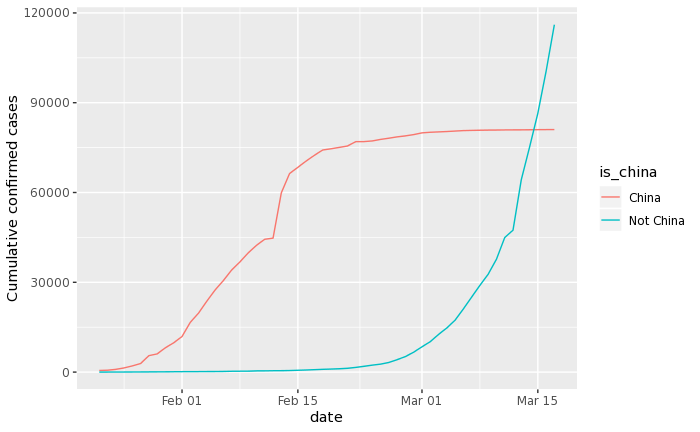

```r
# Drawing a line plot of cum cases vs. date, grouped and colored by is_china
plt_cum_confirmed_cases_china_vs_world <- ggplot(confirmed_cases_china_vs_world) +
  geom_line(aes(date, cum_cases, group=is_china, col=is_china)) +
  ylab("Cumulative confirmed cases")
# See the plot
plt_cum_confirmed_cases_china_vs_world
```

# 4. Let’s Annotate!

## The two lines shown above have very doferent shrape. This tells us that the cases in china became steady and had very less growth as compared to the rest of the world. After march 01, the cases rose rapidly which can be seen by the huge slope in the graph above.

## By annotating events like this, we can better interpret changes in the plot.

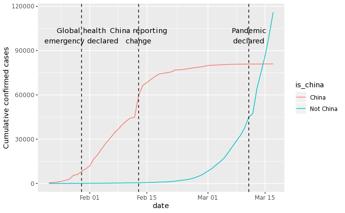

```r
who_events <- tribble(
  ~ date, ~ event,
  "2020-01-30", "Global health\nemergency declared",
  "2020-03-11", "Pandemic\ndeclared",
  "2020-02-13", "China reporting\nchange"
) %>%
  mutate(date = as.Date(date))
# Using who_events, add vertical dashed lines with an xintercept at date
# and text at date, labeled by event, and at 100000 on the y-axis
plt_cum_confirmed_cases_china_vs_world +
  geom_vline(aes(xintercept=date), data=who_events, linetype='dashed') +
  geom_text(aes(x=date, label=event), data=who_events, y=1e5)
```

# 5.Adding trend line to china

## In this, we are just going to add a trend line to the china data visualization. When trying to assess how big future problems are going to be, we need a measure of how fast the number of cases is growing. A good starting point is to see if the cases are growing faster or slower than linearly.

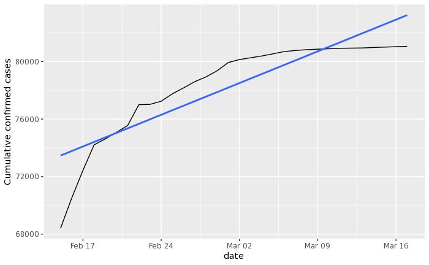

```r
# Filter for China, from Feb 15
china_after_feb15 <- confirmed_cases_china_vs_world %>%
  filter(is_china=='China', date>="2020-02-15")
# Using china_after_feb15, draw a line plot cum_cases vs. date
# Add a smooth trend line using linear regression, no error bars
ggplot(china_after_feb15, aes(date, cum_cases)) +
  geom_line() +
  geom_smooth(method='lm', se=FALSE) +
  ylab("Cumulative confirmed cases")
```

# 6.And the rest of the world?

## From the plot above, the growth rate in China is slower than linear. That’s great news because it indicates China has at least somewhat contained the virus in late February and early March.

## How does the rest of the world compare to linear growth?

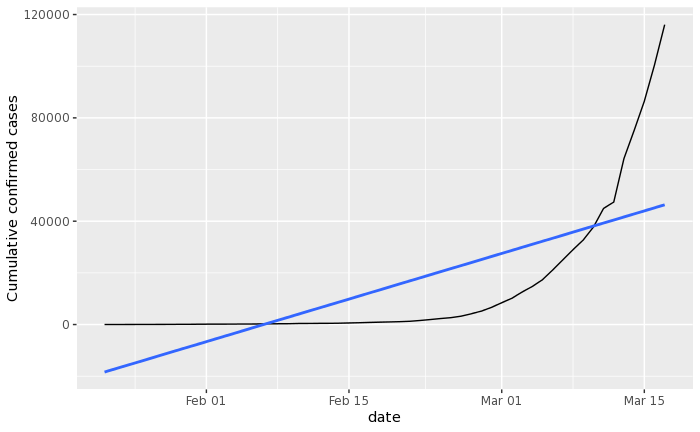

```r
# Filter confirmed_cases_china_vs_world for not China
not_china <- confirmed_cases_china_vs_world %>%
    filter(is_china!='China')
# Using not_china, draw a line plot cum_cases vs. date
# Add a smooth trend line using linear regression, no error bars
plt_not_china_trend_lin <- ggplot(not_china, aes(date, cum_cases)) +
  geom_line() +
  geom_smooth(method='lm', se=FALSE) +
  ylab("Cumulative confirmed cases")
# See the result
plt_not_china_trend_lin
```

# 7.Adding a logarithmic scale

## From the plot above, we can see a straight line does not fit well at all, and the rest of the world is growing much faster than linearly. What if we added a logarithmic scale to the y-axis?

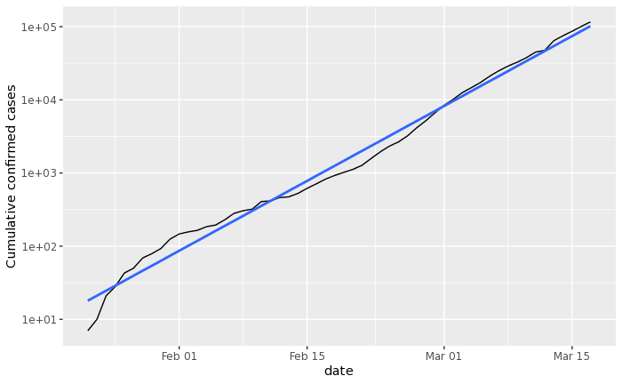

```r
# Modify the plot to use a logarithmic scale on the y-axis
plt_not_china_trend_lin +
  scale_y_log10()
```

# 8.Which countries outside of China have been hit hardest?

## With the logarithmic scale, we get a much closer fit to the data. From a data science point of view, a good fit is great news. Unfortunately, from a public health point of view, that means that cases of COVID-19 in the rest of the world are growing at an exponential rate, which is terrible news.

## Not all countries are being affected by COVID-19 equally, and it would be helpful to know where in the world the problems are greatest. Let’s find the countries outside of China with the most confirmed cases in our dataset.

```r
# Run this to get the data for each country
confirmed_cases_by_country <- read_csv("confirmed_cases_by_country.csv")
glimpse(confirmed_cases_by_country)
```

```
Observations: 13,272
Variables: 5
$ country   <chr> "Afghanistan", "Albania", "Algeria", "Andorra", "Antigua and Barbuda", "Argentina", "Armen…
$ province  <chr> NA, NA, NA, NA, NA, NA, NA, NA, NA, NA, NA, NA, NA, NA, NA, NA, NA, NA, NA, NA, NA, NA, NA…
$ date      <date> 2020-01-22, 2020-01-22, 2020-01-22, 2020-01-22, 2020-01-22, 2020-01-22, 2020-01-22, 2020-…
$ cases     <dbl> 0, 0, 0, 0, 0, 0, 0, 0, 0, 0, 0, 0, 0, 0, 0, 0, 0, 0, 0, 0, 0, 0, 0, 0, 0, 0, 0, 0, 0, 0, …
$ cum_cases <dbl> 0, 0, 0, 0, 0, 0, 0, 0, 0, 0, 0, 0, 0, 0, 0, 0, 0, 0, 0, 0, 0, 0, 0, 0, 0, 0, 0, 0, 0, 0, …
```

```r
# Group by country, summarize to calculate total cases, find the top 7
top_countries_by_total_cases <- confirmed_cases_by_country %>%
  group_by(country) %>%
  summarize(total_cases = max(cum_cases)) %>%
  top_n(7)
# See the result
top_countries_by_total_cases
```

| country | total_cases |
| --- | --- |
| France | 7699 |
| Germany | 9257 |
| Iran | 16169 |
| Italy | 31506 |
| Korea, South | 8320 |
| Spain | 11748 |
| US | 6421 |

# 9.Plotting hardest hit countries as of Mid-March 2020

## Even though the outbreak was first identified in China, there is only one country from East Asia (South Korea) in the above table. Four of the listed countries (France, Germany, Italy, and Spain) are in Europe and share borders. To get more context, we can plot these countries’ confirmed cases over time.

```r
# Run this to get the data for the top 7 countries
confirmed_cases_top7_outside_china <- read_csv('confirmed_cases_top7_outside_china.csv')
#
glimpse(confirmed_cases_top7_outside_china)
```

```
Observations: 2,030
Variables: 3
$ country   <chr> "Germany", "Iran", "Italy", "Korea, South", "Spain", "US", "US", "US", "US", "US", "US", "…
$ date      <date> 2020-02-18, 2020-02-18, 2020-02-18, 2020-02-18, 2020-02-18, 2020-02-18, 2020-02-18, 2020-…
$ cum_cases <dbl> 16, 0, 3, 31, 2, 13, 13, 13, 13, 13, 13, 13, 13, 13, 13, 13, 12, 12, 12, 13, 13, 12, 13, 1…
```

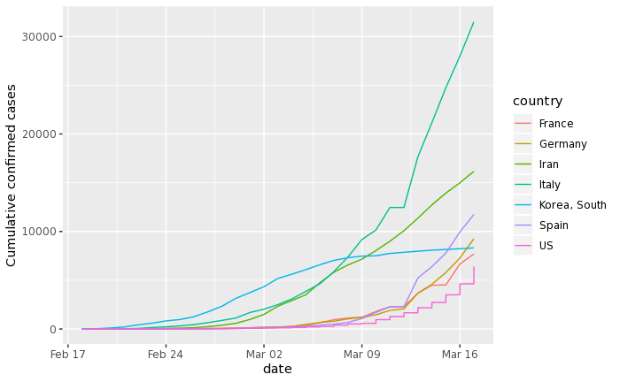

```r
# Using confirmed_cases_top7_outside_china, draw a line plot of
# cum_cases vs. date, grouped and colored by country
ggplot(confirmed_cases_top7_outside_china, aes(date, cum_cases)) +
geom_line(aes(group=country, col=country)) +
ylab('Cumulative confirmed cases')
```

## One of the most difficult challenge was to get some datasets which were good and made sense. I initially had some different data sets i got from WHO, but later i found datasets on github on some account. I downloaded the datasets from there and uploaded them in the R studio online.